# Load data

In this notebook, I'll show how to load cluster data using the XCOP-standard reduced data. This means data are reduced in the 0.7-1.2 keV band with a procedure detailed in Ghirardini & al. 2019 and Ettori & al. 2019. This is done using the `Cluster` class. First, we must define the path to the data.

```python
import astropy.units as u
from xsb_fluc.data.cluster import Cluster

cluster = Cluster(
    imglink='data/A2142/mosaic_a2142.fits.gz',
    explink='data/A2142/mosaic_a2142_expo.fits.gz',
    bkglink='data/A2142/mosaic_a2142_bkg.fits.gz',
    reglink='data/A2142/src_ps.reg',
    nhlink='data/A2142/A2142_nh.fits',
    ra=239.58615,
    dec=27.229433,
    r_500=1.403*u.Mpc,
    redshift=0.09,
)
```

```
WARNING: FITSFixedWarning: RADECSYS= 'FK5 ' / Stellar reference frame
the RADECSYS keyword is deprecated, use RADESYSa. [astropy.wcs.wcs]
WARNING: FITSFixedWarning: EQUINOX = '2000.0 ' / Coordinate system equinox
a floating-point value was expected. [astropy.wcs.wcs]
```

Let's plot it !

```python
cluster.plot_cluster()
```

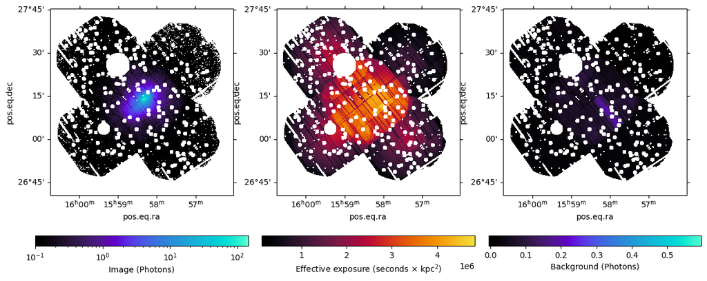

I implemented convenience functions to reduce the size of the images to a given fraction of $R_{500}$ using only the center and size supplied when creating the `Cluster`.

```python
cluster.reduce_to_r500(r500_cut=1).plot_cluster()
```

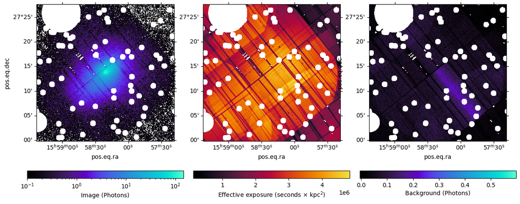

```python
cluster.reduce_to_r500(r500_cut=1).rebin(8).plot_cluster()
```

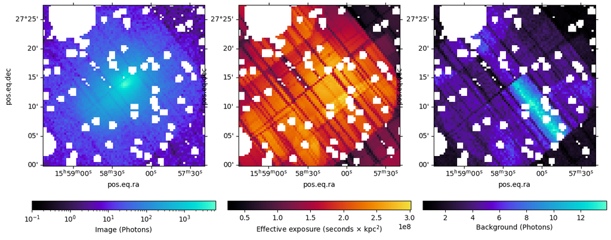